# Notebook Documentation

- Gabriel Wendell Celestino Rocha$^{*}$

$^{*}$gabrielwendell@fisica.ufrn.br

## 1. Introduction & Context

- This notebook documents the Topological Data Analysis (TDA) pipeline for detecting gravitational-wave-like signals under low signal-to-noise ratios (SNRs). Also, this notebook consolidates the diagnostic plots, statistical summaries, and interpretative notes that support the DSML 2025 poster figures.

**Pipeline**

> **Signal Generation** $\implies$ **Embedding** $\implies$ **Persistent Homology** $\implies$ **Vectorization (PI, PL, BC)** $\implies$ **Analysis**

## 2. Load Environment & Dependencies

```python
import os, json, csv
import numpy as np
import pandas as pd
import matplotlib.pyplot as plt
import smplotlib
import seaborn as sns
from mpl_toolkits.axes_grid1 import make_axes_locatable
```

## 3. Load Persistence Data

Access precomputed persistence diagrams and diagnostics.

```python
pd_index = pd.read_csv('../data/pd/index.csv')
pd_stats = pd.read_csv('../results/diag/pd_stats_by_snr.csv')
stability = pd.read_csv('../results/diag/stability_index.csv')
```

- `pd_index` stores metadata about PD files;
- `pd_stats` summarizes topological features by SNR;
- `stability` quantifies bottleneck distances under small perturbations.

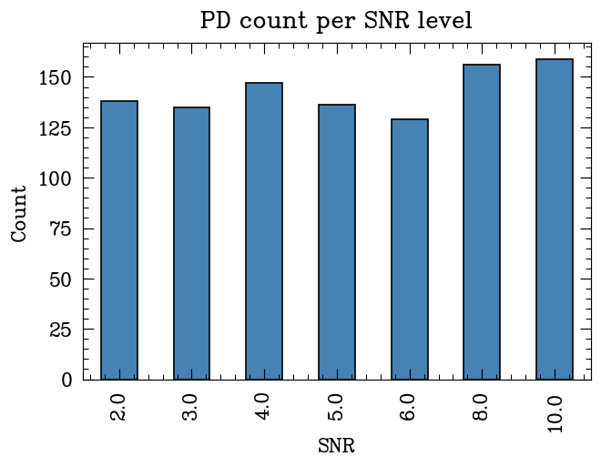

```python
plt.figure(figsize = (6,4))
pd_index['snr_target'].value_counts().sort_index().plot(kind = 'bar', color = 'steelblue', ec = 'k')
plt.xlabel('SNR'); plt.ylabel('Count'); plt.title('PD count per SNR level')
plt.show()
```

## Visualize Persistence Diagram Examples

Display representative PDs for increasing SNRs.

- `fe0a1c6f6a6743d08d95690b6147c460` $\equiv$ `snr2`
- `a590d014fa734b8dadb859650704d7fe` $\equiv$ `snr5`
- `4f38e6e75d994cdcb7a4f62b84ae345c` $\equiv$ `snr10`

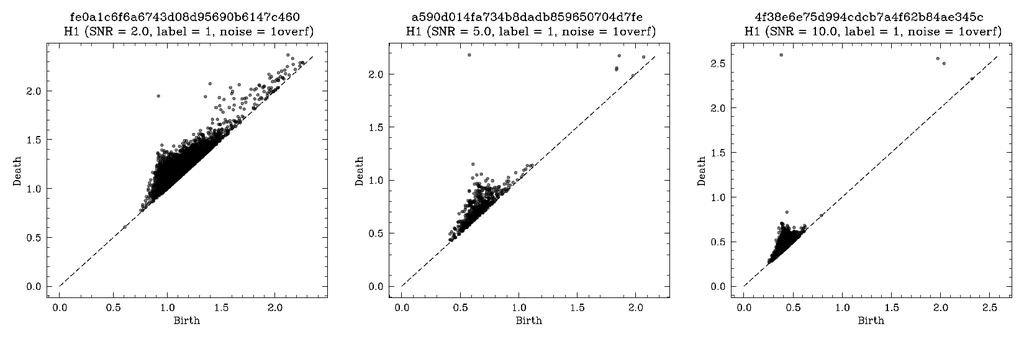

```python
import matplotlib.image as mpimg

examples = ['fe0a1c6f6a6743d08d95690b6147c460',
            'a590d014fa734b8dadb859650704d7fe',
            '4f38e6e75d994cdcb7a4f62b84ae345c']
fig, axes = plt.subplots(1, 3, figsize = (14,5))
for i, ex in enumerate(examples):
    img = mpimg.imread(f'../results/diag/pd_scatter_{ex}_H1.png')
    axes[i].imshow(img, origin = 'upper'); axes[i].axis('off');
plt.tight_layout()
```

- H1 diagrams show a clear transition from diffuse, near-diagonal features (low SNR) to distinct long-lived loops (high SNR).

## 5. Visualize Feature Grids (PI, PL, BC)

### Persistence Images (PI):

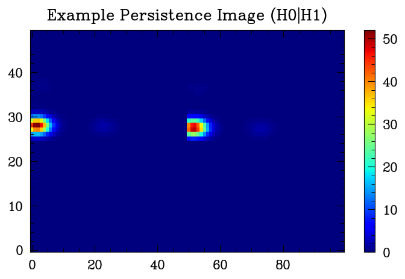

```python
pi = np.load('../data/pi/features_train.npy')
img = pi[0].reshape(50,50*2)
plt.figure(figsize = (7,4))
plt.imshow(img, origin = 'lower', cmap = 'jet', aspect = 'auto')
plt.title('Example Persistence Image (H0|H1)'); plt.colorbar()
```

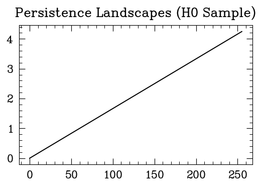

```python
pl = np.load('../data/pl/features_train.npy')[0]
plt.figure(figsize = (5,3)); plt.plot(pl[:256]); plt.title('Persistence Landscapes (H0 Sample)')
```

- Vectorized representations (PI, PL, BC) provide fixed-size feature vectors that capture the statistical geometry of PDs, suitable for ML models.

## 6. Stability Analysis

Examine topological stability under embedding perturbations.

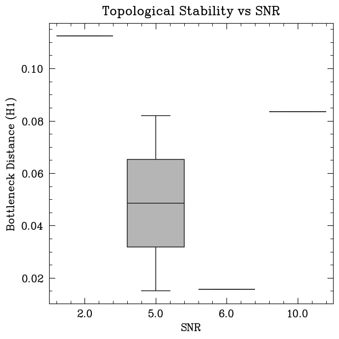

```python
sns.boxplot(x = 'snr_target', y = 'dH1_mean', data = stability, palette = 'Greys')
plt.xlabel('SNR'); plt.ylabel('Bottleneck Distance (H1)')
plt.title('Topological Stability vs SNR')
plt.tight_layout()
```

## 7. Cross-Feature Correlations

Compare mean feature profiles across PI, PL, and BC.

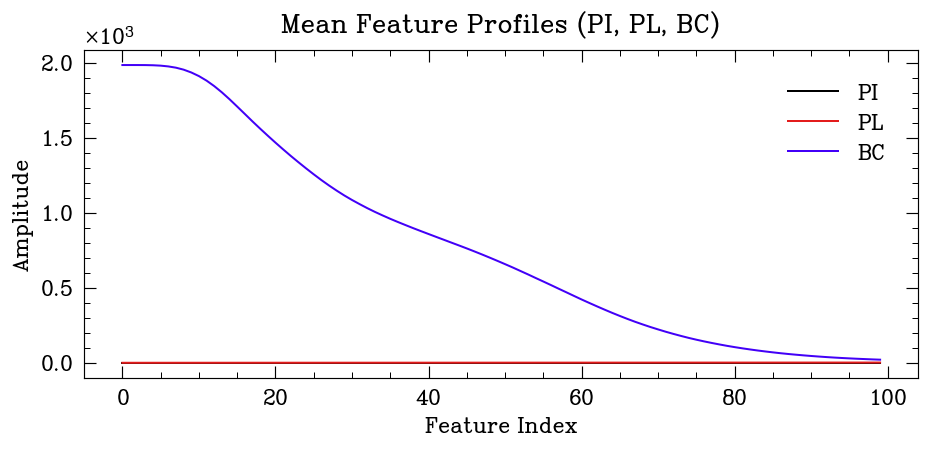

```python
pi_mean = np.mean(np.load('../data/pi/features_train.npy'), axis = 0)
pl_mean = np.mean(np.load('../data/pl/features_train.npy'), axis = 0)
bc_mean = np.mean(np.load('../data/bc/features_train.npy'), axis = 0)


plt.figure(figsize = (8,4))
plt.plot(pi_mean[:100], label = 'PI')
plt.plot(pl_mean[:100], label = 'PL')
plt.plot(bc_mean[:100], label = 'BC')
plt.legend(); plt.title('Mean Feature Profiles (PI, PL, BC)')
plt.xlabel('Feature Index'); plt.ylabel('Amplitude')
plt.tight_layout()
```

## 8. Conclusions & Next Steps

**Next steps**

- Begin Phase 3: Machine Learning pipeline for classification.
- Use PIs, PLs, and BCs as feature inputs.
- Extend to real interferometer noise for validation.

## 9. Save & Export

Include both in code and markdown:

```python
!jupyter nbconvert --to html Phase2_TDA_Analysis.ipynb
```

```
[NbConvertApp] Converting notebook Phase2_TDA_Analysis.ipynb to html
[NbConvertApp] Writing 604516 bytes to Phase2_TDA_Analysis.html
```